# rprogbasics-contd

David Raj

20 May 2017

Install and load the necessary packages if packages are not present already install using install.packages(“packagename”)

```r
library(tidyverse)
```

```r
library(dplyr)
library(ggplot2)
library(nycflights13)
```

dplyr basic funtions

SELECT,FILTER,ARRANGE,PIPELINING(not command but redirecting using %>%),MUTATE,SUMMARIZE

```r
select(mtcars,mpg:hp)
```

```
##                      mpg cyl  disp  hp
## Mazda RX4           21.0   6 160.0 110
## Mazda RX4 Wag       21.0   6 160.0 110
## Datsun 710          22.8   4 108.0  93
## Hornet 4 Drive      21.4   6 258.0 110
## Hornet Sportabout   18.7   8 360.0 175
## Valiant             18.1   6 225.0 105
## Duster 360          14.3   8 360.0 245
## Merc 240D           24.4   4 146.7  62
## Merc 230            22.8   4 140.8  95
## Merc 280            19.2   6 167.6 123
## Merc 280C           17.8   6 167.6 123
## Merc 450SE          16.4   8 275.8 180
## Merc 450SL          17.3   8 275.8 180
## Merc 450SLC         15.2   8 275.8 180
## Cadillac Fleetwood  10.4   8 472.0 205
## Lincoln Continental 10.4   8 460.0 215
## Chrysler Imperial   14.7   8 440.0 230
## Fiat 128            32.4   4  78.7  66
## Honda Civic         30.4   4  75.7  52
## Toyota Corolla      33.9   4  71.1  65
## Toyota Corona       21.5   4 120.1  97
## Dodge Challenger    15.5   8 318.0 150
## AMC Javelin         15.2   8 304.0 150
## Camaro Z28          13.3   8 350.0 245
## Pontiac Firebird    19.2   8 400.0 175
## Fiat X1-9           27.3   4  79.0  66
## Porsche 914-2       26.0   4 120.3  91
## Lotus Europa        30.4   4  95.1 113
## Ford Pantera L      15.8   8 351.0 264
## Ferrari Dino        19.7   6 145.0 175
## Maserati Bora       15.0   8 301.0 335
## Volvo 142E          21.4   4 121.0 109
```

```r
select(mtcars,contains("m"))
```

```
##                      mpg am
## Mazda RX4           21.0  1
## Mazda RX4 Wag       21.0  1
## Datsun 710          22.8  1
## Hornet 4 Drive      21.4  0
## Hornet Sportabout   18.7  0
## Valiant             18.1  0
## Duster 360          14.3  0
## Merc 240D           24.4  0
## Merc 230            22.8  0
## Merc 280            19.2  0
## Merc 280C           17.8  0
## Merc 450SE          16.4  0
## Merc 450SL          17.3  0
## Merc 450SLC         15.2  0
## Cadillac Fleetwood  10.4  0
## Lincoln Continental 10.4  0
## Chrysler Imperial   14.7  0
## Fiat 128            32.4  1
## Honda Civic         30.4  1
## Toyota Corolla      33.9  1
## Toyota Corona       21.5  0
## Dodge Challenger    15.5  0
## AMC Javelin         15.2  0
## Camaro Z28          13.3  0
## Pontiac Firebird    19.2  0
## Fiat X1-9           27.3  1
## Porsche 914-2       26.0  1
## Lotus Europa        30.4  1
## Ford Pantera L      15.8  1
## Ferrari Dino        19.7  1
## Maserati Bora       15.0  1
## Volvo 142E          21.4  1
```

```r
select(mtcars,starts_with("m"))
```

```
##                      mpg
## Mazda RX4           21.0
## Mazda RX4 Wag       21.0
## Datsun 710          22.8
## Hornet 4 Drive      21.4
## Hornet Sportabout   18.7
## Valiant             18.1
## Duster 360          14.3
## Merc 240D           24.4
## Merc 230            22.8
## Merc 280            19.2
## Merc 280C           17.8
## Merc 450SE          16.4
## Merc 450SL          17.3
## Merc 450SLC         15.2
## Cadillac Fleetwood  10.4
## Lincoln Continental 10.4
## Chrysler Imperial   14.7
## Fiat 128            32.4
## Honda Civic         30.4
## Toyota Corolla      33.9
## Toyota Corona       21.5
## Dodge Challenger    15.5
## AMC Javelin         15.2
## Camaro Z28          13.3
## Pontiac Firebird    19.2
## Fiat X1-9           27.3
## Porsche 914-2       26.0
## Lotus Europa        30.4
## Ford Pantera L      15.8
## Ferrari Dino        19.7
## Maserati Bora       15.0
## Volvo 142E          21.4
```

```r
select(mtcars,ends_with("m"))
```

```
##                     am
## Mazda RX4            1
## Mazda RX4 Wag        1
## Datsun 710           1
## Hornet 4 Drive       0
## Hornet Sportabout    0
## Valiant              0
## Duster 360           0
## Merc 240D            0
## Merc 230             0
## Merc 280             0
## Merc 280C            0
## Merc 450SE           0
## Merc 450SL           0
## Merc 450SLC          0
## Cadillac Fleetwood   0
## Lincoln Continental  0
## Chrysler Imperial    0
## Fiat 128             1
## Honda Civic          1
## Toyota Corolla       1
## Toyota Corona        0
## Dodge Challenger     0
## AMC Javelin          0
## Camaro Z28           0
## Pontiac Firebird     0
## Fiat X1-9            1
## Porsche 914-2        1
## Lotus Europa         1
## Ford Pantera L       1
## Ferrari Dino         1
## Maserati Bora        1
## Volvo 142E           1
```

```r
select(flights,-(year:day))
```

```
## # A tibble: 336,776 × 16
##    dep_time sched_dep_time dep_delay arr_time sched_arr_time arr_delay
##       <int>          <int>     <dbl>    <int>          <int>     <dbl>
## 1       517            515         2      830            819        11
## 2       533            529         4      850            830        20
## 3       542            540         2      923            850        33
## 4       544            545        -1     1004           1022       -18
## 5       554            600        -6      812            837       -25
## 6       554            558        -4      740            728        12
## 7       555            600        -5      913            854        19
## 8       557            600        -3      709            723       -14
## 9       557            600        -3      838            846        -8
## 10      558            600        -2      753            745         8
## # ... with 336,766 more rows, and 10 more variables: carrier <chr>,
## #   flight <int>, tailnum <chr>, origin <chr>, dest <chr>, air_time <dbl>,
## #   distance <dbl>, hour <dbl>, minute <dbl>, time_hour <dttm>
```

```r
rename(flights,tail_num=tailnum)
```

```
## # A tibble: 336,776 × 19
##     year month   day dep_time sched_dep_time dep_delay arr_time
##    <int> <int> <int>    <int>          <int>     <dbl>    <int>
## 1   2013     1     1      517            515         2      830
## 2   2013     1     1      533            529         4      850
## 3   2013     1     1      542            540         2      923
## 4   2013     1     1      544            545        -1     1004
## 5   2013     1     1      554            600        -6      812
## 6   2013     1     1      554            558        -4      740
## 7   2013     1     1      555            600        -5      913
## 8   2013     1     1      557            600        -3      709
## 9   2013     1     1      557            600        -3      838
## 10  2013     1     1      558            600        -2      753
## # ... with 336,766 more rows, and 12 more variables: sched_arr_time <int>,
## #   arr_delay <dbl>, carrier <chr>, flight <int>, tail_num <chr>,
## #   origin <chr>, dest <chr>, air_time <dbl>, distance <dbl>, hour <dbl>,
## #   minute <dbl>, time_hour <dttm>
```

```r
select(flights,distance,everything())
```

```
## # A tibble: 336,776 × 19
##    distance  year month   day dep_time sched_dep_time dep_delay arr_time
##       <dbl> <int> <int> <int>    <int>          <int>     <dbl>    <int>
## 1      1400  2013     1     1      517            515         2      830
## 2      1416  2013     1     1      533            529         4      850
## 3      1089  2013     1     1      542            540         2      923
## 4      1576  2013     1     1      544            545        -1     1004
## 5       762  2013     1     1      554            600        -6      812
## 6       719  2013     1     1      554            558        -4      740
## 7      1065  2013     1     1      555            600        -5      913
## 8       229  2013     1     1      557            600        -3      709
## 9       944  2013     1     1      557            600        -3      838
## 10      733  2013     1     1      558            600        -2      753
## # ... with 336,766 more rows, and 11 more variables: sched_arr_time <int>,
## #   arr_delay <dbl>, carrier <chr>, flight <int>, tailnum <chr>,
## #   origin <chr>, dest <chr>, air_time <dbl>, hour <dbl>, minute <dbl>,
## #   time_hour <dttm>
```

```r
filter(mtcars,cyl==6)
```

```
##    mpg cyl  disp  hp drat    wt  qsec vs am gear carb
## 1 21.0   6 160.0 110 3.90 2.620 16.46  0  1    4    4
## 2 21.0   6 160.0 110 3.90 2.875 17.02  0  1    4    4
## 3 21.4   6 258.0 110 3.08 3.215 19.44  1  0    3    1
## 4 18.1   6 225.0 105 2.76 3.460 20.22  1  0    3    1
## 5 19.2   6 167.6 123 3.92 3.440 18.30  1  0    4    4
## 6 17.8   6 167.6 123 3.92 3.440 18.90  1  0    4    4
## 7 19.7   6 145.0 175 3.62 2.770 15.50  0  1    5    6
```

```r
filter(mtcars,cyl==6,hp==110)
```

```
##    mpg cyl disp  hp drat    wt  qsec vs am gear carb
## 1 21.0   6  160 110 3.90 2.620 16.46  0  1    4    4
## 2 21.0   6  160 110 3.90 2.875 17.02  0  1    4    4
## 3 21.4   6  258 110 3.08 3.215 19.44  1  0    3    1
```

```r
filter(mtcars,cyl %in% c(4,6))
```

```
##     mpg cyl  disp  hp drat    wt  qsec vs am gear carb
## 1  21.0   6 160.0 110 3.90 2.620 16.46  0  1    4    4
## 2  21.0   6 160.0 110 3.90 2.875 17.02  0  1    4    4
## 3  22.8   4 108.0  93 3.85 2.320 18.61  1  1    4    1
## 4  21.4   6 258.0 110 3.08 3.215 19.44  1  0    3    1
## 5  18.1   6 225.0 105 2.76 3.460 20.22  1  0    3    1
## 6  24.4   4 146.7  62 3.69 3.190 20.00  1  0    4    2
## 7  22.8   4 140.8  95 3.92 3.150 22.90  1  0    4    2
## 8  19.2   6 167.6 123 3.92 3.440 18.30  1  0    4    4
## 9  17.8   6 167.6 123 3.92 3.440 18.90  1  0    4    4
## 10 32.4   4  78.7  66 4.08 2.200 19.47  1  1    4    1
## 11 30.4   4  75.7  52 4.93 1.615 18.52  1  1    4    2
## 12 33.9   4  71.1  65 4.22 1.835 19.90  1  1    4    1
## 13 21.5   4 120.1  97 3.70 2.465 20.01  1  0    3    1
## 14 27.3   4  79.0  66 4.08 1.935 18.90  1  1    4    1
## 15 26.0   4 120.3  91 4.43 2.140 16.70  0  1    5    2
## 16 30.4   4  95.1 113 3.77 1.513 16.90  1  1    5    2
## 17 19.7   6 145.0 175 3.62 2.770 15.50  0  1    5    6
## 18 21.4   4 121.0 109 4.11 2.780 18.60  1  1    4    2
```

```r
mtcars %>% select(mpg,cyl,disp) %>% filter(cyl==6)
```

```
##    mpg cyl  disp
## 1 21.0   6 160.0
## 2 21.0   6 160.0
## 3 21.4   6 258.0
## 4 18.1   6 225.0
## 5 19.2   6 167.6
## 6 17.8   6 167.6
## 7 19.7   6 145.0
```

```r
arrange(mtcars,desc(cyl,mpg))
```

```
##     mpg cyl  disp  hp drat    wt  qsec vs am gear carb
## 1  18.7   8 360.0 175 3.15 3.440 17.02  0  0    3    2
## 2  14.3   8 360.0 245 3.21 3.570 15.84  0  0    3    4
## 3  16.4   8 275.8 180 3.07 4.070 17.40  0  0    3    3
## 4  17.3   8 275.8 180 3.07 3.730 17.60  0  0    3    3
## 5  15.2   8 275.8 180 3.07 3.780 18.00  0  0    3    3
## 6  10.4   8 472.0 205 2.93 5.250 17.98  0  0    3    4
## 7  10.4   8 460.0 215 3.00 5.424 17.82  0  0    3    4
## 8  14.7   8 440.0 230 3.23 5.345 17.42  0  0    3    4
## 9  15.5   8 318.0 150 2.76 3.520 16.87  0  0    3    2
## 10 15.2   8 304.0 150 3.15 3.435 17.30  0  0    3    2
## 11 13.3   8 350.0 245 3.73 3.840 15.41  0  0    3    4
## 12 19.2   8 400.0 175 3.08 3.845 17.05  0  0    3    2
## 13 15.8   8 351.0 264 4.22 3.170 14.50  0  1    5    4
## 14 15.0   8 301.0 335 3.54 3.570 14.60  0  1    5    8
```

[output cut: 18 more lines]

```r
mutate(mtcars,newhp=hp+10)
```

```
##     mpg cyl  disp  hp drat    wt  qsec vs am gear carb newhp
## 1  21.0   6 160.0 110 3.90 2.620 16.46  0  1    4    4   120
## 2  21.0   6 160.0 110 3.90 2.875 17.02  0  1    4    4   120
## 3  22.8   4 108.0  93 3.85 2.320 18.61  1  1    4    1   103
## 4  21.4   6 258.0 110 3.08 3.215 19.44  1  0    3    1   120
## 5  18.7   8 360.0 175 3.15 3.440 17.02  0  0    3    2   185
## 6  18.1   6 225.0 105 2.76 3.460 20.22  1  0    3    1   115
## 7  14.3   8 360.0 245 3.21 3.570 15.84  0  0    3    4   255
## 8  24.4   4 146.7  62 3.69 3.190 20.00  1  0    4    2    72
## 9  22.8   4 140.8  95 3.92 3.150 22.90  1  0    4    2   105
## 10 19.2   6 167.6 123 3.92 3.440 18.30  1  0    4    4   133
## 11 17.8   6 167.6 123 3.92 3.440 18.90  1  0    4    4   133
## 12 16.4   8 275.8 180 3.07 4.070 17.40  0  0    3    3   190
## 13 17.3   8 275.8 180 3.07 3.730 17.60  0  0    3    3   190
## 14 15.2   8 275.8 180 3.07 3.780 18.00  0  0    3    3   190
```

[output cut: 18 more lines]

```r
head(mtcars)
```

```
##                    mpg cyl disp  hp drat    wt  qsec vs am gear carb
## Mazda RX4         21.0   6  160 110 3.90 2.620 16.46  0  1    4    4
## Mazda RX4 Wag     21.0   6  160 110 3.90 2.875 17.02  0  1    4    4
## Datsun 710        22.8   4  108  93 3.85 2.320 18.61  1  1    4    1
## Hornet 4 Drive    21.4   6  258 110 3.08 3.215 19.44  1  0    3    1
## Hornet Sportabout 18.7   8  360 175 3.15 3.440 17.02  0  0    3    2
## Valiant           18.1   6  225 105 2.76 3.460 20.22  1  0    3    1
```

```r
mtcars=mutate(mtcars,newhp=hp)

transmute(flights,gain=arr_delay-dep_delay)
```

```
## # A tibble: 336,776 × 1
##     gain
##    <dbl>
## 1      9
## 2     16
## 3     31
## 4    -17
## 5    -19
## 6     16
## 7     24
## 8    -11
## 9     -5
## 10    10
## # ... with 336,766 more rows
```

```r
mtcars %>% group_by(cyl) %>% summarise(avg_mpg=mean(mpg))
```

```
## # A tibble: 3 × 2
##     cyl  avg_mpg
##   <dbl>    <dbl>
## 1     4 26.66364
## 2     6 19.74286
## 3     8 15.10000
```

GGPLOT2 basics This document will discuss 1) Scatter plot 2) Bar plot 3) lineplot 4) boxplot

There are different ways of plotting the best one is the grammer of graphics using ggplot2 , in addition there are other ways like base plotting ,lattice plotting and quick way using qplot

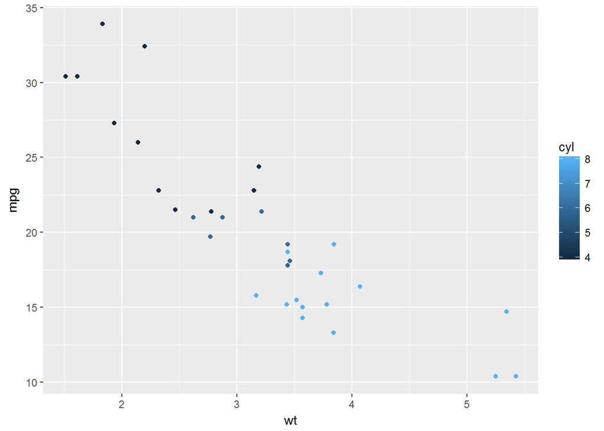

```r
ggplot(data=mtcars,aes(x=wt,y=mpg,col=cyl)) + geom_point()
```

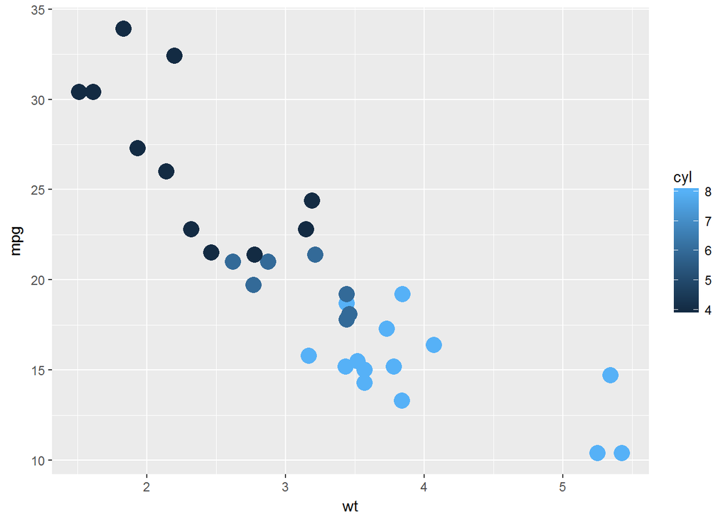

```r
ggplot(data=mtcars,aes(x=wt,y=mpg,col=cyl)) + geom_point(size=5)
```

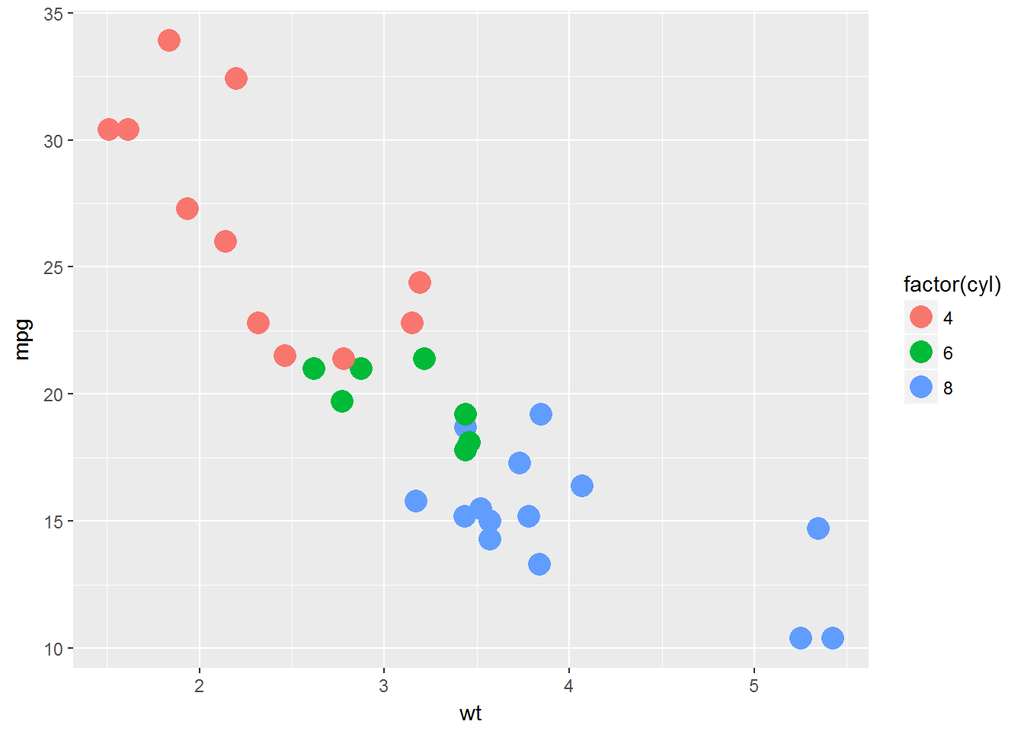

```r
ggplot(data=mtcars,aes(x=wt,y=mpg,col=factor(cyl))) + geom_point(size=5)
```

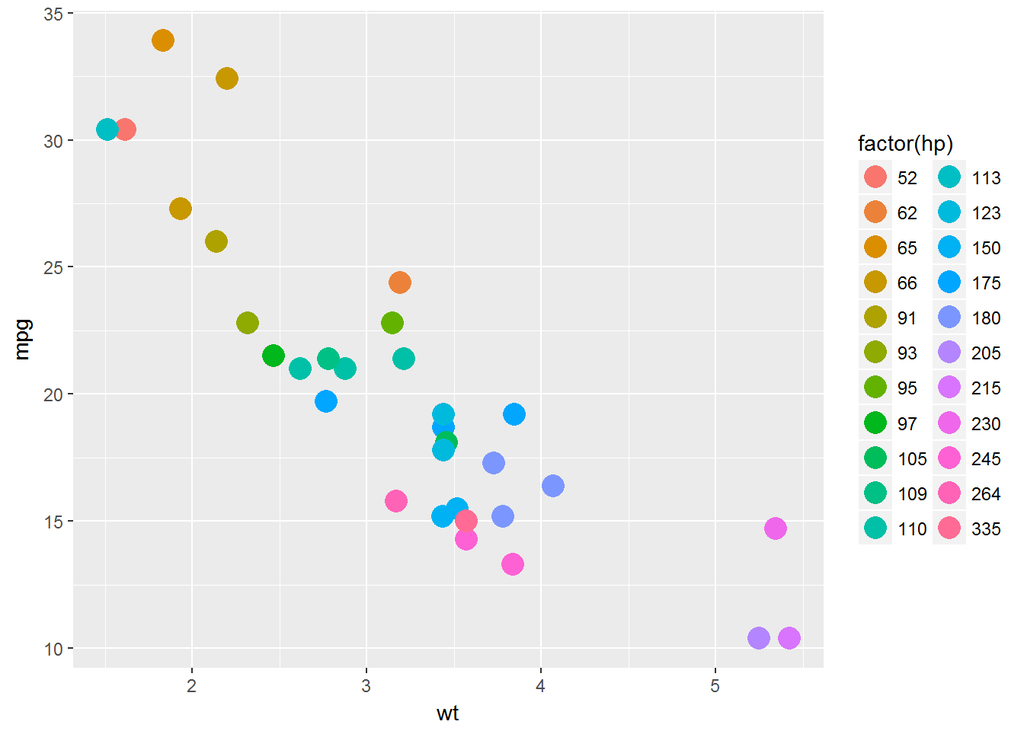

```r
ggplot(data=mtcars,aes(x=wt,y=mpg,col=factor(hp))) + geom_point(size=5)
```

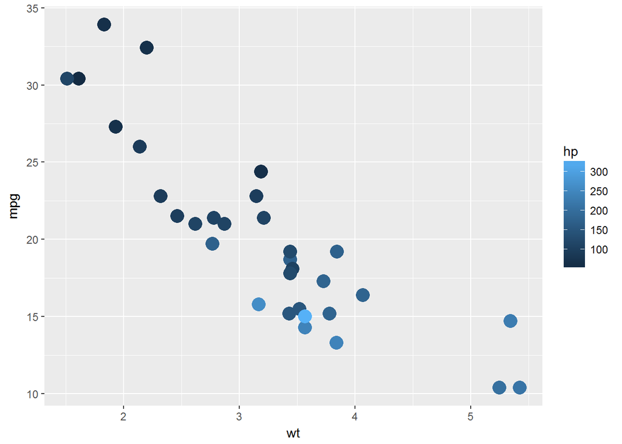

```r
ggplot(data=mtcars,aes(x=wt,y=mpg,col=hp)) + geom_point(size=5)
```

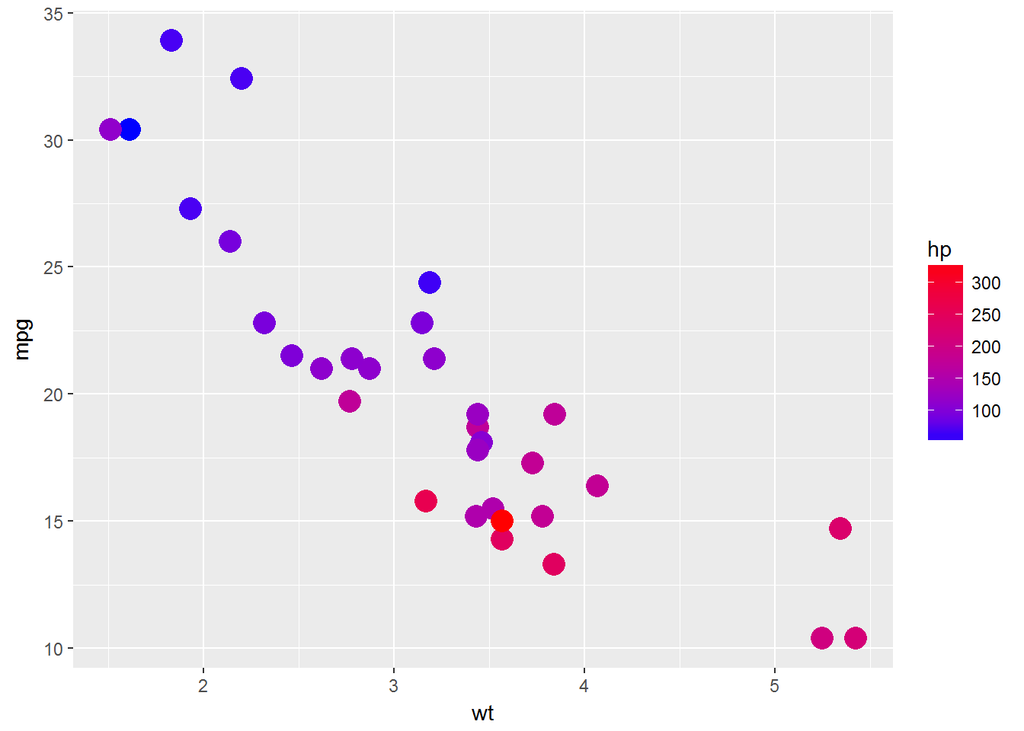

```r
ggplot(data=mtcars,aes(x=wt,y=mpg,col=hp)) + geom_point(size=5)+scale_color_gradient(low="blue",high="red")
```

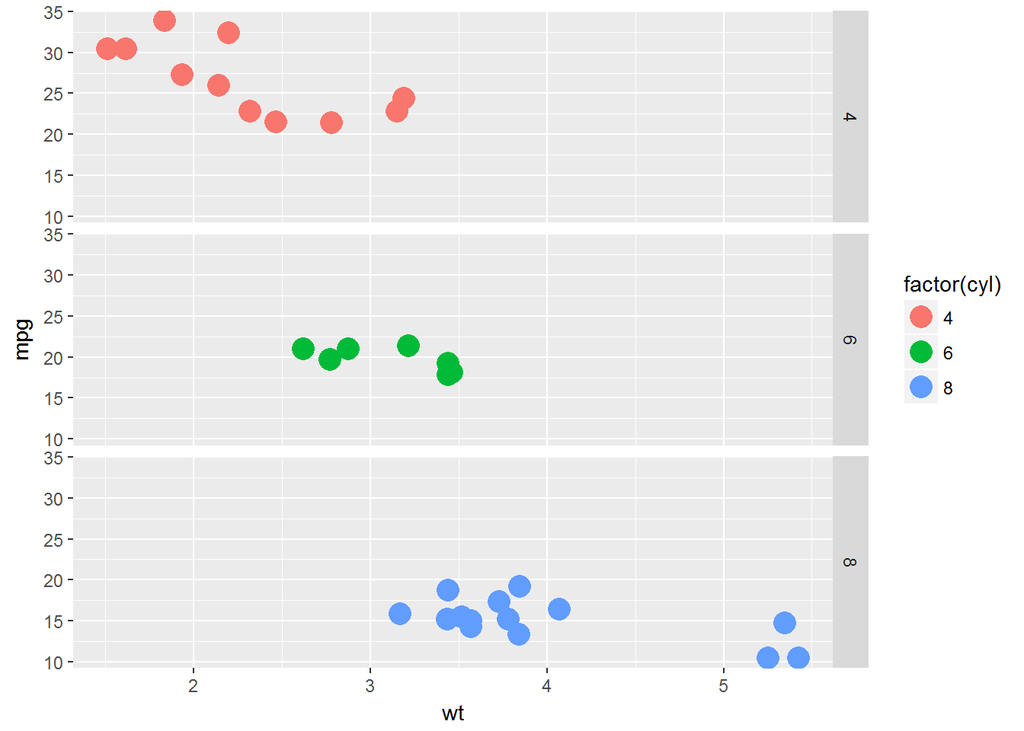

```r
ggplot(data=mtcars,aes(x=wt,y=mpg,col=factor(cyl))) + geom_point(size=5)+facet_grid(cyl~.)
```

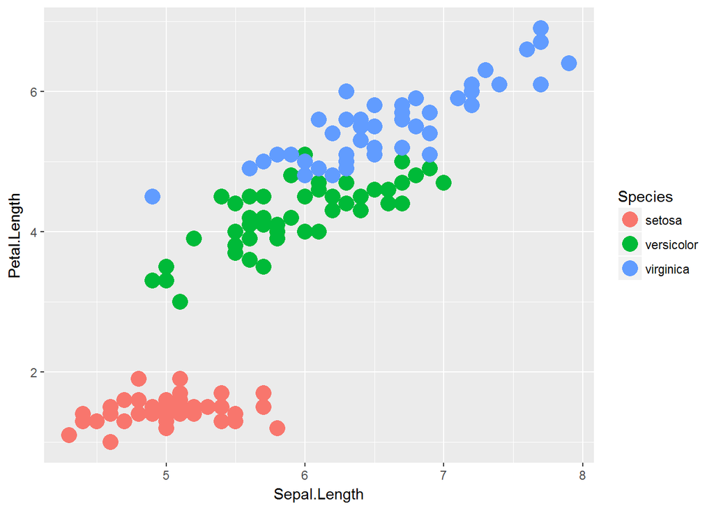

```r
ggplot(data=iris,aes(x=Sepal.Length,y=Petal.Length,col=Species))+ geom_point(size=5)
```

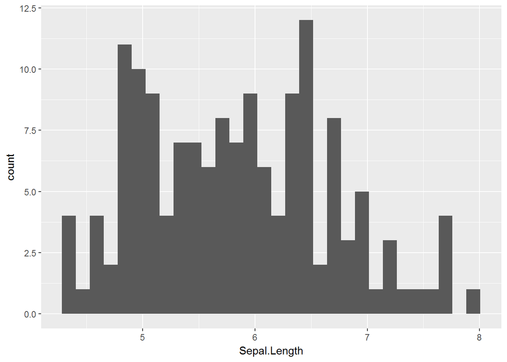

```r
ggplot(data=iris,aes(x=Sepal.Length))+geom_histogram()
```

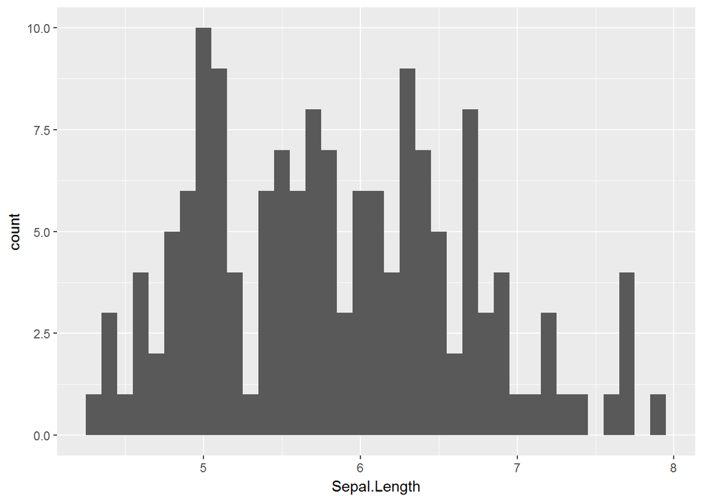

```r
ggplot(data=iris,aes(x=Sepal.Length))+geom_histogram(binwidth=0.1)
```

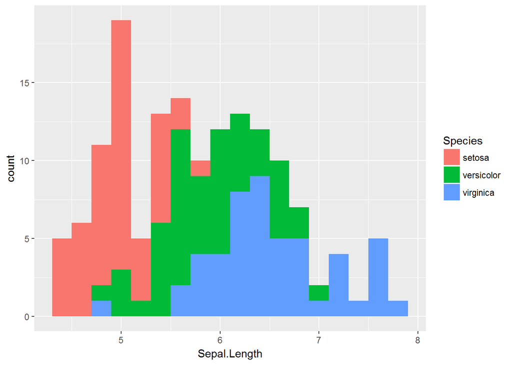

```r
ggplot(data=iris,aes(x=Sepal.Length,fill=Species))+geom_histogram(binwidth=0.2)
```

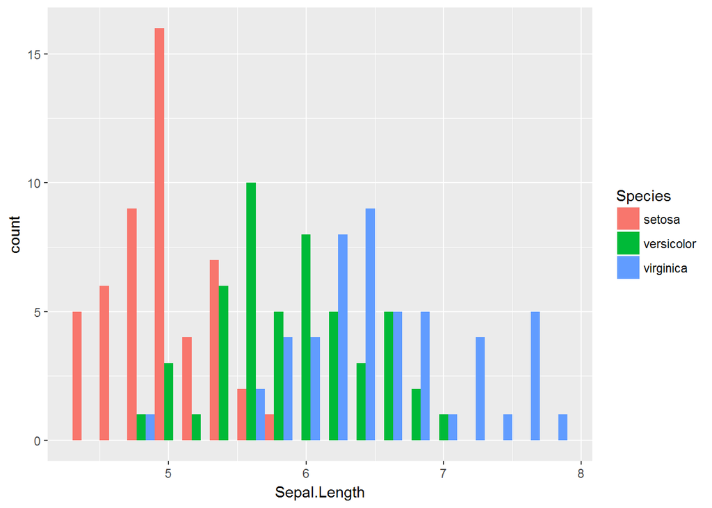

```r
ggplot(data=iris,aes(x=Sepal.Length,fill=Species))+geom_histogram(binwidth=0.2,position="dodge")
```

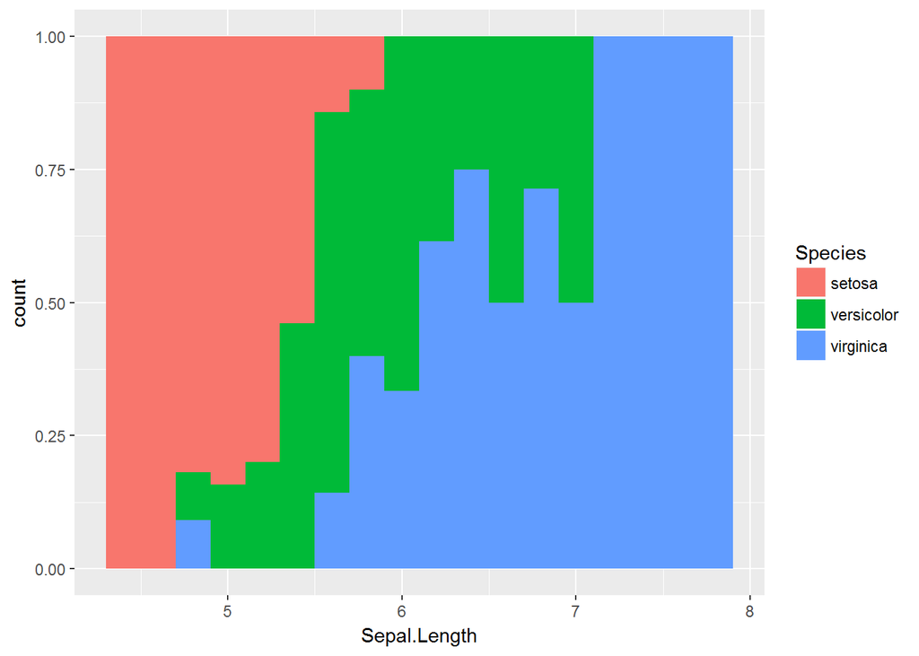

```r
ggplot(data=iris,aes(x=Sepal.Length,fill=Species))+geom_histogram(binwidth=0.2,position="fill")
```

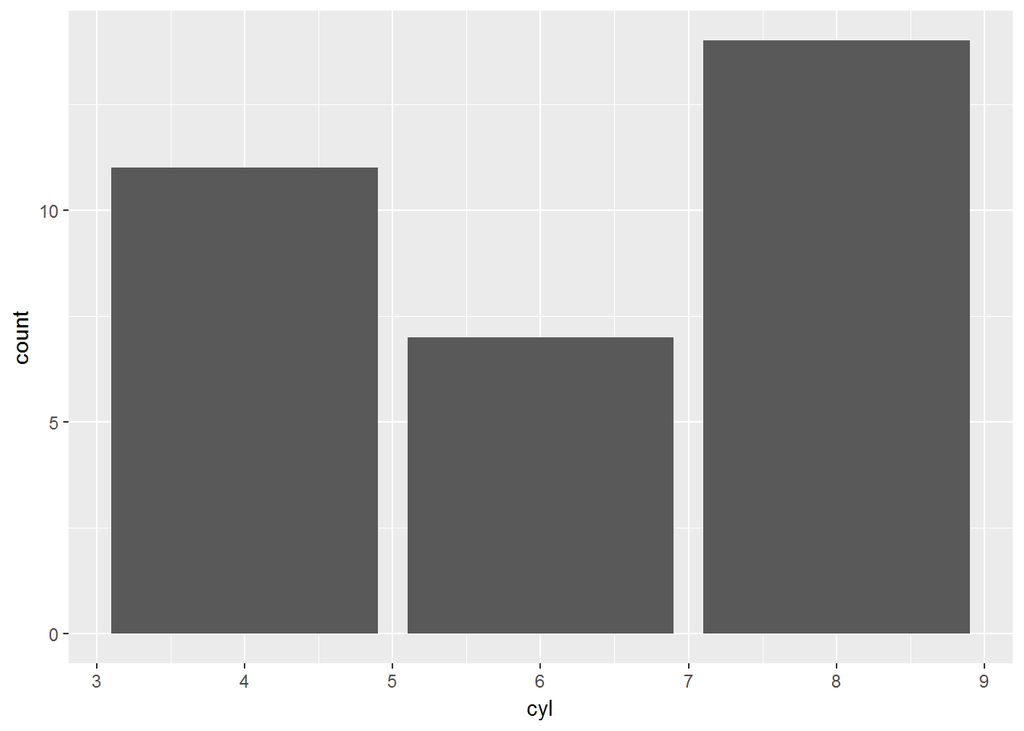

```r
posn_d=position_dodge(0.2)

ggplot(data=mtcars,aes(x=cyl,fill=am))+geom_bar(position=posn_d)
```

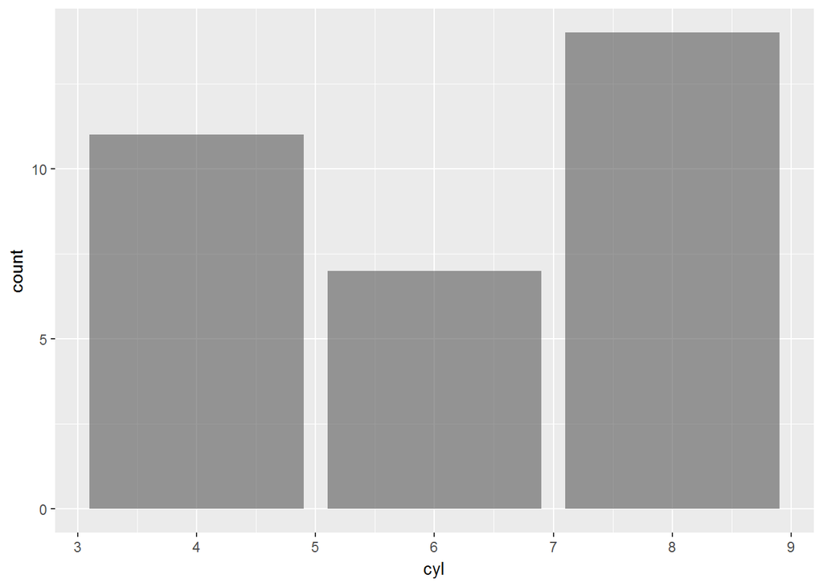

```r
ggplot(data=mtcars,aes(x=cyl,fill=am))+geom_bar(position=posn_d,alpha=0.6)
```

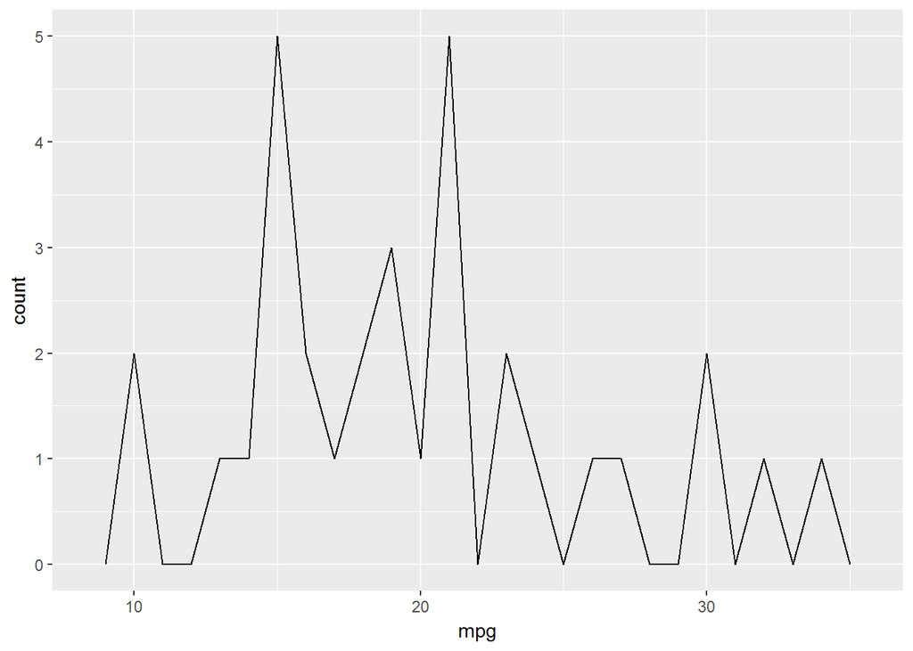

```r
ggplot(mtcars, aes(mpg, col = cyl)) +  geom_freqpoly(binwidth = 1)
```

```r
head(economics)
```

```
## # A tibble: 6 × 6
##         date   pce    pop psavert uempmed unemploy
##       <date> <dbl>  <int>   <dbl>   <dbl>    <int>
## 1 1967-07-01 507.4 198712    12.5     4.5     2944
## 2 1967-08-01 510.5 198911    12.5     4.7     2945
## 3 1967-09-01 516.3 199113    11.7     4.6     2958
## 4 1967-10-01 512.9 199311    12.5     4.9     3143
## 5 1967-11-01 518.1 199498    12.5     4.7     3066
## 6 1967-12-01 525.8 199657    12.1     4.8     3018
```

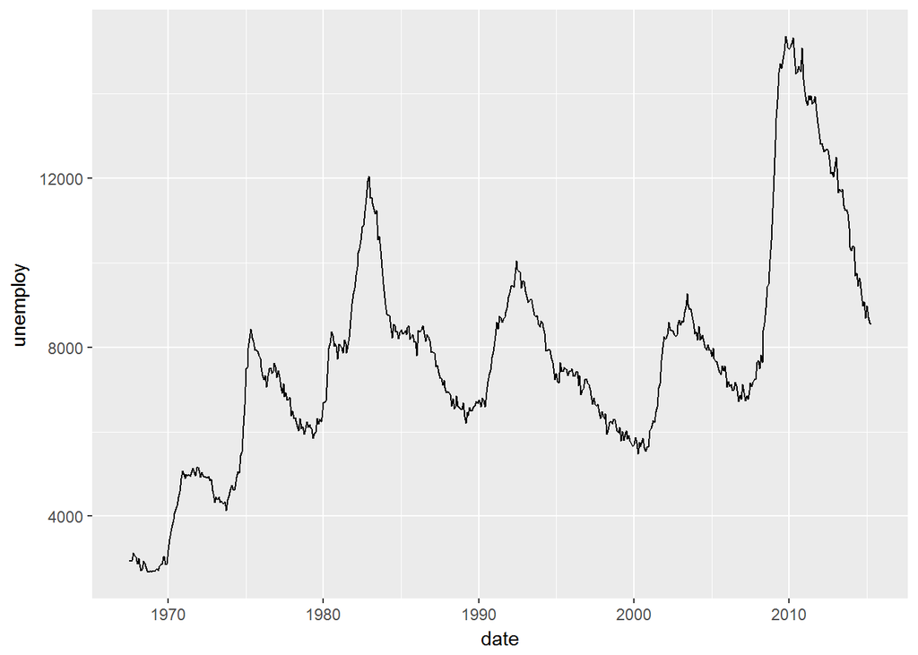

```r
ggplot(economics, aes(x = date, y = unemploy)) +geom_line()
```

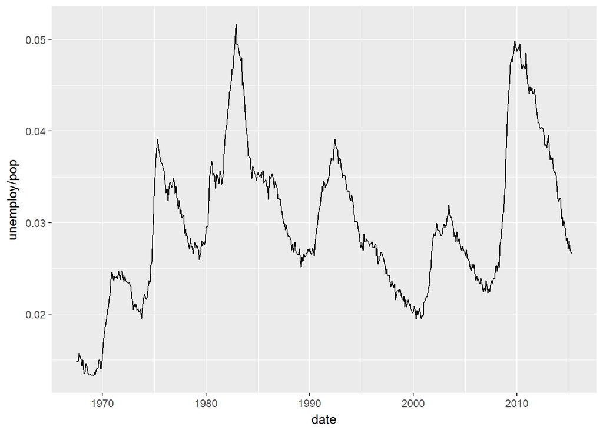

```r
ggplot(economics, aes(x = date, y = unemploy/pop)) +geom_line()
```

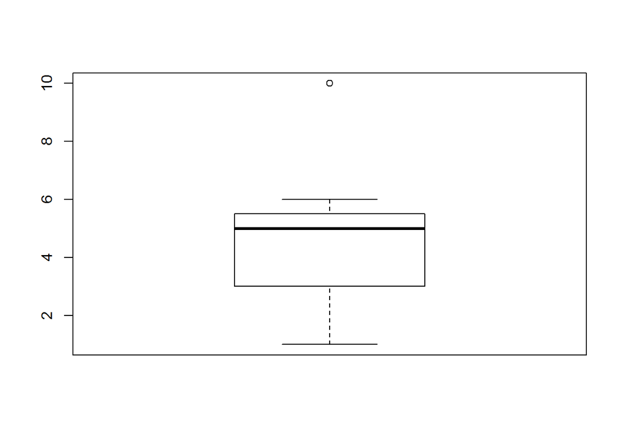

```r
sal= c(1,2,5,6,5,4,10)

boxplot(sal)
```

In the scatter plot 1 though the cylinder variable takes values 4,6 and 8 the values are shown as continous in the legend this is corrected in the subsequent plots by applying the factor of the variable bar plot is generally used to get the frequency of occurence or data distribution. Line plot is mostly used for time series data. Box plot is another simple way of getting the data distribution also getting the outliers. review the data and the plots and they are self explanatory

TIDY DATA: using some of the tidy verse package commands we can clean the data to get it into popular tabular format. GATHER is database equivalent of unpivot SPREAD is database equivalent of pivot SEPERATE to split UNITE to concatenate

```r
table2
```

```
## # A tibble: 12 × 4
##        country  year       type      count
##          <chr> <int>      <chr>      <int>
## 1  Afghanistan  1999      cases        745
## 2  Afghanistan  1999 population   19987071
## 3  Afghanistan  2000      cases       2666
## 4  Afghanistan  2000 population   20595360
## 5       Brazil  1999      cases      37737
## 6       Brazil  1999 population  172006362
## 7       Brazil  2000      cases      80488
## 8       Brazil  2000 population  174504898
## 9        China  1999      cases     212258
## 10       China  1999 population 1272915272
## 11       China  2000      cases     213766
## 12       China  2000 population 1280428583
```

```r
table3
```

```
## # A tibble: 6 × 3
##       country  year              rate
## *       <chr> <int>             <chr>
## 1 Afghanistan  1999      745/19987071
## 2 Afghanistan  2000     2666/20595360
## 3      Brazil  1999   37737/172006362
## 4      Brazil  2000   80488/174504898
## 5       China  1999 212258/1272915272
## 6       China  2000 213766/1280428583
```

```r
table4a
```

```
## # A tibble: 3 × 3
##       country `1999` `2000`
## *       <chr>  <int>  <int>
## 1 Afghanistan    745   2666
## 2      Brazil  37737  80488
## 3       China 212258 213766
```

```r
table5
```

```
## # A tibble: 6 × 4
##       country century  year              rate
## *       <chr>   <chr> <chr>             <chr>
## 1 Afghanistan      19    99      745/19987071
## 2 Afghanistan      20    00     2666/20595360
## 3      Brazil      19    99   37737/172006362
## 4      Brazil      20    00   80488/174504898
## 5       China      19    99 212258/1272915272
## 6       China      20    00 213766/1280428583
```

```r
table4a %>% gather(`1999`,`2000`,key="year",value="population")
```

```
## # A tibble: 6 × 3
##       country  year population
##         <chr> <chr>      <int>
## 1 Afghanistan  1999        745
## 2      Brazil  1999      37737
## 3       China  1999     212258
## 4 Afghanistan  2000       2666
## 5      Brazil  2000      80488
## 6       China  2000     213766
```

```r
table2 %>% spread(key=type,value=count)
```

```
## # A tibble: 6 × 4
##       country  year  cases population
## *       <chr> <int>  <int>      <int>
## 1 Afghanistan  1999    745   19987071
## 2 Afghanistan  2000   2666   20595360
## 3      Brazil  1999  37737  172006362
## 4      Brazil  2000  80488  174504898
## 5       China  1999 212258 1272915272
## 6       China  2000 213766 1280428583
```

```r
table3 %>% separate(rate,into=c("cases","population"),sep="/")
```

```
## # A tibble: 6 × 4
##       country  year  cases population
## *       <chr> <int>  <chr>      <chr>
## 1 Afghanistan  1999    745   19987071
## 2 Afghanistan  2000   2666   20595360
## 3      Brazil  1999  37737  172006362
## 4      Brazil  2000  80488  174504898
## 5       China  1999 212258 1272915272
## 6       China  2000 213766 1280428583
```

```r
table5 %>% unite(nyear,century,year,sep="")
```

```
## # A tibble: 6 × 3
##       country nyear              rate
## *       <chr> <chr>             <chr>
## 1 Afghanistan  1999      745/19987071
## 2 Afghanistan  2000     2666/20595360
## 3      Brazil  1999   37737/172006362
## 4      Brazil  2000   80488/174504898
## 5       China  1999 212258/1272915272
## 6       China  2000 213766/1280428583
```

Joins using dplyr - Lets create some dummy tables and issue inner and outer joins.

```r
x = tribble(~key,~val_x,1,"x1",2,"x2",3,"x3")
y = tribble(~key,~val_y,1,"y1",2,"y2",4,"y4")
x %>% left_join(y,by="key")
```

```
## # A tibble: 3 × 3
##     key val_x val_y
##   <dbl> <chr> <chr>
## 1     1    x1    y1
## 2     2    x2    y2
## 3     3    x3  <NA>
```

```r
x %>% right_join(y,by="key")
```

```
## # A tibble: 3 × 3
##     key val_x val_y
##   <dbl> <chr> <chr>
## 1     1    x1    y1
## 2     2    x2    y2
## 3     4  <NA>    y4
```

```r
x %>% full_join(y,by="key")
```

```
## # A tibble: 4 × 3
##     key val_x val_y
##   <dbl> <chr> <chr>
## 1     1    x1    y1
## 2     2    x2    y2
## 3     3    x3  <NA>
## 4     4  <NA>    y4
```

```r
x %>% inner_join(y,by="key")
```

```
## # A tibble: 2 × 3
##     key val_x val_y
##   <dbl> <chr> <chr>
## 1     1    x1    y1
## 2     2    x2    y2
```

```r
flights2 <- flights %>% select(-origin,-dest) %>% left_join(airlines,by="carrier")
topdest <- flights %>% count(dest,sort=TRUE) %>% head(10)
topdestfullname <- topdest %>% left_join(airports,by=c("dest"="faa"))
flights %>% semi_join(topdest)
```

```
## # A tibble: 141,145 × 19
##     year month   day dep_time sched_dep_time dep_delay arr_time
##    <int> <int> <int>    <int>          <int>     <dbl>    <int>
## 1   2013     1     1      554            558        -4      740
## 2   2013     1     1      558            600        -2      753
## 3   2013     1     1      608            600         8      807
## 4   2013     1     1      629            630        -1      824
## 5   2013     1     1      656            700        -4      854
## 6   2013     1     1      709            700         9      852
## 7   2013     1     1      715            713         2      911
## 8   2013     1     1      739            745        -6      918
## 9   2013     1     1      749            710        39      939
## 10  2013     1     1      828            830        -2     1027
## # ... with 141,135 more rows, and 12 more variables: sched_arr_time <int>,
## #   arr_delay <dbl>, carrier <chr>, flight <int>, tailnum <chr>,
## #   origin <chr>, dest <chr>, air_time <dbl>, distance <dbl>, hour <dbl>,
## #   minute <dbl>, time_hour <dttm>
```

```r
flights %>% anti_join(planes,by="tailnum") %>% count(tailnum,sort=TRUE)
```

```
## # A tibble: 722 × 2
##    tailnum     n
##      <chr> <int>
## 1     <NA>  2512
## 2   N725MQ   575
## 3   N722MQ   513
## 4   N723MQ   507
## 5   N713MQ   483
## 6   N735MQ   396
## 7   N0EGMQ   371
## 8   N534MQ   364
## 9   N542MQ   363
## 10  N531MQ   349
## # ... with 712 more rows
```

These commands are self explanatory. This concludes basics of dplyr,ggplot2,tidyverse 3 crucial packages in R in addition to the base package. This will help to do lot of cleaning, transformation and visualization of data.